# Year of Death

# 1 Description of DataSchema variable

The description of harmonised variable is the following:

- Short name: `ydeath`
- Variable label: `Year of death`
- Variable description: `Year of death`
- Domain: `Death`
- Value type: `Continuous`
- Category missings:

| **Code** | **Category Label** |
| --- | --- |
| 991 | CAPI/interviewer error |
| 992 | Impute |
| 993 | Disable to measure |
| 994 | Not attempt/not done |
| 995 | Does not answer |
| 996 | Not applicable |
| 997 | Refuse |
| 998 | Do not know |
| 999 | Missing |

# 2 Data process

## 2.1 England

### 2.1.1 Wave non-specific

#### 2.1.1.1 Study-specific variable description

| **Name** | `yrdeath` |
| --- | --- |
| **Label** | `Year of death - updated Feb 2012` |
| **Table name** | `index_file_wave_0-wave_5_v2` |
| **Units** | `years` |
| **Missings** | `-3 = Details being checked with ONS` `-2 = Information not available or not applicable` |
| **Description** |  |

yrdeath

| Sample size | Missing values |
| --- | --- |
| 37938 | 32882 |

Type of missing

|  | -2 | -3 | NA |
| --- | --- | --- | --- |
| Frequency | 32882.00 | 0 | 0 |
| Percentage | 86.67 | 0 | 0 |

(en) Year of death - updated Feb 2012

|  | 1995 | 1998 | 1999 | 2000 | 2001 | 2002 | 2003 | 2004 | 2005 | 2006 | 2007 | 2008 | 2009 | 2010 | 2011 | 2012 |
| --- | --- | --- | --- | --- | --- | --- | --- | --- | --- | --- | --- | --- | --- | --- | --- | --- |
| Frequency | 1 | 73.00 | 176.00 | 229.0 | 310.00 | 391.00 | 412.00 | 390.00 | 405.00 | 406.00 | 392.00 | 463.00 | 457.0 | 441.00 | 423.00 | 87.00 |
| Percentage | 0 | 0.19 | 0.46 | 0.6 | 0.82 | 1.03 | 1.09 | 1.03 | 1.07 | 1.07 | 1.03 | 1.22 | 1.2 | 1.16 | 1.11 | 0.23 |

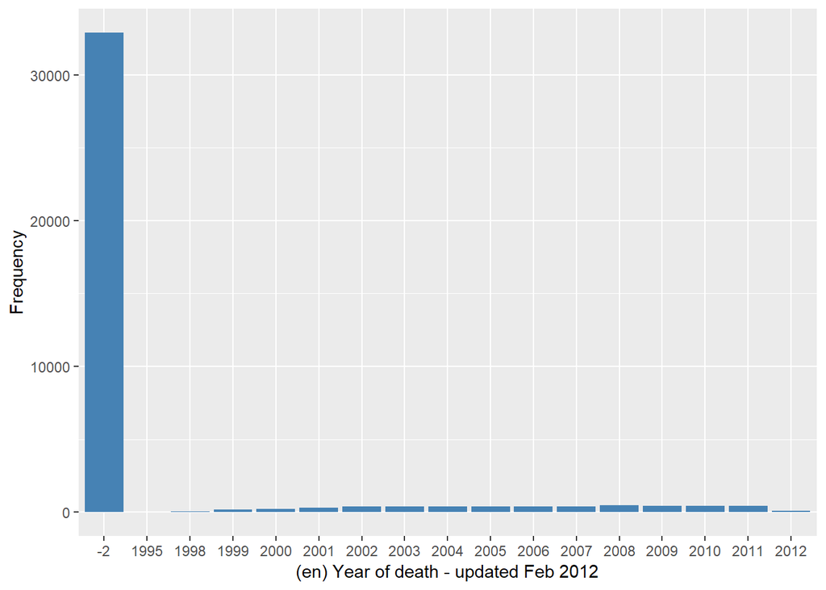

#### 2.1.1.2 Harmonisation algorithm

- `Priorize year of death taken from official mortality data (the National Health Service Central Register)`
- `Otherwise, keep years of death answered in EOL interviews`
- `Correct an impossible year of death with the given in EOL interview`
- `harmonise those id's dead during wave n (2000 + n*2,2001 + n*2) in wave n if they do not participate in it or otherwise in wave n+1`

**R script:**

```r
# Individuals with potential information on death and in some wave up to 0.
# Values -2,-3 of yrdeath have no useful information to harmonise
elsa <- elsa %>% filter(id %in% Reduce(union, list(core1$id, core2$id, core3$id,
    core4$id, core5$id, core6$id, core7$id))) %>% mutate_at("yrdeath", ~replace(.,
    list = which(. %in% c(-2, -3)), values = NA)) %>% filter_at(vars(-id), any_vars(!is.na(.)))
# elsa <- elsa %>% filter(id %in%
# Reduce(union,list(core1$id,core2$id,core3$id,core4$id,core5$id,core6$id,core7$id)))
# %>% mutate_at('yrdeath',~replace(.,list = which(. %in% c(-2,-3)), values =
# NA)) %>% mutate_at('mortstat',~replace(.,list = which(. %in% c(-1,-0)),
# values = NA)) %>% filter_at(vars(-id),any_vars(!is.na(.)))

# Individuals in EoL interviews not interviewed in any wave from 1 are
# removed. We keep them only in first EoL interview they appear.  Printed
# lengths of cases 135 - 1 = 134
ids2 <- (eol2 %>% filter(id %in% Reduce(union, list(core1$id, core2$id))))$id
# 375 - 1 = 374
ids3 <- setdiff((eol3 %>% filter(id %in% Reduce(union, list(core1$id, core2$id,
    core3$id))))$id, eol2$id)
# 242 -1 - 4 = 237
ids4 <- setdiff((eol4 %>% filter(id %in% Reduce(union, list(core1$id, core2$id,
    core3$id, core4$id))))$id, union(eol2$id, eol3$id))
# 240
ids6 <- setdiff((eol6 %>% filter(id %in% Reduce(union, list(core1$id, core2$id,
    core3$id, core4$id, core5$id, core6$id))))$id, Reduce(union, list(eol2$id,
    eol3$id, eol4$id)))
# 134 + 374 + 237 + 240 = 985
ids <- Reduce(union, list(ids2, ids3, ids4, ids6))

eol <- full_join(eol2 %>% filter(id %in% ids2), eol3 %>% filter(id %in% ids3),
    by = "id", suffix = c(".w2", ".w3"))
eol <- full_join(eol, eol4 %>% filter(id %in% ids4), by = "id")
eol <- full_join(eol, eol6 %>% filter(id %in% ids6), by = "id", suffix = c(".w4",
    ".w6"))
eol <- eol %>% mutate(EiDateY = coalesce(EiDateY.w2, EiDateY.w3, EiDateY.w4,
    EiDateY.w6))

# elsa_eol <- full_join(eol %>% select(id,EiDateY) %>%
# mutate_at('EiDateY',~replace(.,list = which(. %in% c(-8,2000)), values =
# NA)), elsa %>% filter(!is.na(yrdeath) | id %in% eol$id), by = 'id')

# Priorize year of death taken from official mortality data (the National
# Health Service Central Register).  Otherwise, keep years of death answered
# in EOL interviews.  Correct an impossible year of death with the given in
# EOL interview.

elsa_eol <- full_join(eol %>% select(id, EiDateY), elsa %>% filter(!is.na(yrdeath) |
    id %in% eol$id), by = "id") %>% mutate(ydeath = coalesce(yrdeath, as.numeric(EiDateY))) %>%
    mutate(ydeath = replace(ydeath, id %in% ids3 & yrdeath == 2010, EiDateY[which(id %in%
        ids3 & yrdeath == 2010)]))


dids2 <- union((elsa_eol %>% filter(ydeath %in% c(2002, 2003)))$id, (elsa_eol %>%
    filter(ydeath %in% c(2004, 2005) & !id %in% core2$id))$id)
dids3 <- setdiff(union((elsa_eol %>% filter(ydeath %in% c(2004, 2005)))$id,
    (elsa_eol %>% filter(ydeath %in% c(2006, 2007) & !id %in% core3$id))$id),
    dids2)
dids4 <- setdiff(union((elsa_eol %>% filter(ydeath %in% c(2006, 2007)))$id,
    (elsa_eol %>% filter(ydeath %in% c(2008, 2009) & !id %in% core4$id))$id),
    dids3)
dids5 <- setdiff(union((elsa_eol %>% filter(ydeath %in% c(2008, 2009)))$id,
    (elsa_eol %>% filter(ydeath %in% c(2010, 2011) & !id %in% core5$id))$id),
    dids4)
dids6 <- setdiff(union((elsa_eol %>% filter(ydeath %in% c(2010, 2011)))$id,
    (elsa_eol %>% filter(ydeath %in% c(2012, 2013) & !id %in% core6$id))$id),
    dids5)
```

Id’s with EOL interview and mortality status = alive have died mainly in 2012

| id | EiDateY | mortstat | yrdeath | ydeath |
| --- | --- | --- | --- | --- |
| 103848 | 2012 | 1 | NA | 2012 |
| 104289 | 2012 | 1 | NA | 2012 |
| 104438 | 2012 | 1 | NA | 2012 |
| 105599 | 2012 | 1 | NA | 2012 |
| 105997 | 2012 | 1 | NA | 2012 |
| 106047 | 2012 | 1 | NA | 2012 |
| 106818 | 2012 | 1 | NA | 2012 |
| 107114 | 2012 | 1 | NA | 2012 |
| 107133 | 2012 | 1 | NA | 2012 |
| 107348 | 2012 | 1 | NA | 2012 |
| 107691 | 2012 | 1 | NA | 2012 |
| 107734 | 2012 | 1 | NA | 2012 |
| 110850 | 2012 | 1 | NA | 2012 |
| 111254 | 2012 | 1 | NA | 2012 |
| 111533 | 2012 | 1 | NA | 2012 |
| 111750 | 2012 | 1 | NA | 2012 |
| 112016 | 2012 | 1 | NA | 2012 |
| 112398 | 2012 | 1 | NA | 2012 |
| 112969 | 2012 | 1 | NA | 2012 |
| 116706 | 2012 | 1 | NA | 2012 |
| 117103 | 2012 | 1 | NA | 2012 |
| 117232 | 2012 | 1 | NA | 2012 |
| 117700 | 2011 | 1 | NA | 2011 |
| 117804 | 2012 | 1 | NA | 2012 |
| 118791 | 2012 | 1 | NA | 2012 |
| 118845 | 2012 | 1 | NA | 2012 |
| 119239 | 2012 | 1 | NA | 2012 |
| 119371 | 2012 | 1 | NA | 2012 |
| 119452 | 2012 | 1 | NA | 2012 |
| 119622 | 2012 | 1 | NA | 2012 |
| 120024 | 2012 | 1 | NA | 2012 |
| 120899 | 2012 | 1 | NA | 2012 |
| 121103 | 2012 | 1 | NA | 2012 |
| 160171 | 2012 | 1 | NA | 2012 |
| 161012 | 2012 | 1 | NA | 2012 |
| 161209 | 2012 | 1 | NA | 2012 |
| 162325 | 2012 | 1 | NA | 2012 |

Id’s with associated wave 2 EOL interview have died before 2006

| val | frq | label | raw.prc | valid.prc | cum.prc |
| --- | --- | --- | --- | --- | --- |
| 2002 | 22 |  | 16.42 | 17.6 | 17.6 |
| 2003 | 70 |  | 52.24 | 56.0 | 73.6 |
| 2004 | 32 |  | 23.88 | 25.6 | 99.2 |
| 2005 | 1 |  | 0.75 | 0.8 | 100.0 |
| NA | 9 |  | 6.72 | NA | NA |

Years of death given in wave 2 EOL interview are previous to 2006

| val | frq | label | raw.prc | valid.prc | cum.prc |
| --- | --- | --- | --- | --- | --- |
| 2002 | 24 |  | 17.91 | 17.91 | 17.91 |
| 2003 | 73 |  | 54.48 | 54.48 | 72.39 |
| 2004 | 36 |  | 26.87 | 26.87 | 99.25 |
| 2005 | 1 |  | 0.75 | 0.75 | 100.00 |
| NA | 0 |  | 0.00 | NA | NA |

There is 1 id with associated wave 3 EOL interview and with death date after 2007

| val | frq | label | raw.prc | valid.prc | cum.prc |
| --- | --- | --- | --- | --- | --- |
| 2002 | 13 |  | 3.48 | 3.76 | 3.76 |
| 2003 | 43 |  | 11.50 | 12.43 | 16.18 |
| 2004 | 78 |  | 20.86 | 22.54 | 38.73 |
| 2005 | 119 |  | 31.82 | 34.39 | 73.12 |
| 2006 | 90 |  | 24.06 | 26.01 | 99.13 |
| 2007 | 2 |  | 0.53 | 0.58 | 99.71 |
| 2010 | 1 |  | 0.27 | 0.29 | 100.00 |
| NA | 28 |  | 7.49 | NA | NA |

This id has died in 2006

| id | EiDateY | mortstat | yrdeath | ydeath |
| --- | --- | --- | --- | --- |
| 112721 | 2006 | 2 | 2010 | 2006 |

Years of death given in wave 3 EOL interview are previous to 2008

| val | frq | label | raw.prc | valid.prc | cum.prc |
| --- | --- | --- | --- | --- | --- |
| 2002 | 14 |  | 3.74 | 3.74 | 3.74 |
| 2003 | 47 |  | 12.57 | 12.57 | 16.31 |
| 2004 | 80 |  | 21.39 | 21.39 | 37.70 |
| 2005 | 125 |  | 33.42 | 33.42 | 71.12 |
| 2006 | 106 |  | 28.34 | 28.34 | 99.47 |
| 2007 | 2 |  | 0.53 | 0.53 | 100.00 |
| NA | 0 |  | 0.00 | NA | NA |

Id’s with associated wave 4 EOL interview have died before 2010

| val | frq | label | raw.prc | valid.prc | cum.prc |
| --- | --- | --- | --- | --- | --- |
| 2005 | 4 |  | 1.69 | 1.84 | 1.84 |
| 2006 | 22 |  | 9.28 | 10.14 | 11.98 |
| 2007 | 55 |  | 23.21 | 25.35 | 37.33 |
| 2008 | 125 |  | 52.74 | 57.60 | 94.93 |
| 2009 | 11 |  | 4.64 | 5.07 | 100.00 |
| NA | 20 |  | 8.44 | NA | NA |

Years of death given in wave 4 EOL interview are previous to 2010

| val | frq | label | raw.prc | valid.prc | cum.prc |
| --- | --- | --- | --- | --- | --- |
| 2004 | 1 |  | 0.42 | 0.42 | 0.42 |
| 2005 | 3 |  | 1.27 | 1.27 | 1.69 |
| 2006 | 23 |  | 9.70 | 9.70 | 11.39 |
| 2007 | 64 |  | 27.00 | 27.00 | 38.40 |
| 2008 | 133 |  | 56.12 | 56.12 | 94.51 |
| 2009 | 13 |  | 5.49 | 5.49 | 100.00 |
| NA | 0 |  | 0.00 | NA | NA |

Id’s with associated wave 6 interview have died before 2014

| val | frq | label | raw.prc | valid.prc | cum.prc |
| --- | --- | --- | --- | --- | --- |
| 2008 | 5 |  | 2.08 | 2.81 | 2.81 |
| 2009 | 53 |  | 22.08 | 29.78 | 32.58 |
| 2010 | 87 |  | 36.25 | 48.88 | 81.46 |
| 2011 | 31 |  | 12.92 | 17.42 | 98.88 |
| 2012 | 2 |  | 0.83 | 1.12 | 100.00 |
| NA | 62 |  | 25.83 | NA | NA |

Years of death given in wave 6 EOL interview are previous to 2014

| val | frq | label | raw.prc | valid.prc | cum.prc |
| --- | --- | --- | --- | --- | --- |
| -8 | 2 |  | 0.83 | 0.83 | 0.83 |
| 2000 | 1 |  | 0.42 | 0.42 | 1.25 |
| 2007 | 1 |  | 0.42 | 0.42 | 1.67 |
| 2008 | 7 |  | 2.92 | 2.92 | 4.58 |
| 2009 | 45 |  | 18.75 | 18.75 | 23.33 |
| 2010 | 87 |  | 36.25 | 36.25 | 59.58 |
| 2011 | 49 |  | 20.42 | 20.42 | 80.00 |
| 2012 | 48 |  | 20.00 | 20.00 | 100.00 |
| NA | 0 |  | 0.00 | NA | NA |

There are 1618 id’s with an impossible year of death (2000) or missing data answered in EOL interviews

| val | frq | label | raw.prc | valid.prc | cum.prc |
| --- | --- | --- | --- | --- | --- |
| -8 | 2 |  | 0.08 | 0.20 | 0.20 |
| 2000 | 1 |  | 0.04 | 0.10 | 0.30 |
| 2002 | 38 |  | 1.46 | 3.86 | 4.16 |
| 2003 | 120 |  | 4.62 | 12.18 | 16.35 |
| 2004 | 117 |  | 4.50 | 11.88 | 28.22 |
| 2005 | 129 |  | 4.96 | 13.10 | 41.32 |
| 2006 | 129 |  | 4.96 | 13.10 | 54.42 |
| 2007 | 67 |  | 2.58 | 6.80 | 61.22 |
| 2008 | 140 |  | 5.38 | 14.21 | 75.43 |
| 2009 | 58 |  | 2.23 | 5.89 | 81.32 |
| 2010 | 87 |  | 3.35 | 8.83 | 90.15 |
| 2011 | 49 |  | 1.88 | 4.97 | 95.13 |
| 2012 | 48 |  | 1.85 | 4.87 | 100.00 |
| NA | 1615 |  | 62.12 | NA | NA |

Their years of death

| val | frq | label | raw.prc | valid.prc | cum.prc |
| --- | --- | --- | --- | --- | --- |
| 2002 | 27 |  | 1.67 | 1.67 | 1.67 |
| 2003 | 106 |  | 6.55 | 6.55 | 8.22 |
| 2004 | 112 |  | 6.92 | 6.92 | 15.14 |
| 2005 | 125 |  | 7.73 | 7.73 | 22.87 |
| 2006 | 137 |  | 8.47 | 8.47 | 31.33 |
| 2007 | 183 |  | 11.31 | 11.31 | 42.65 |
| 2008 | 164 |  | 10.14 | 10.14 | 52.78 |
| 2009 | 228 |  | 14.09 | 14.09 | 66.87 |
| 2010 | 198 |  | 12.24 | 12.24 | 79.11 |
| 2011 | 275 |  | 17.00 | 17.00 | 96.11 |
| 2012 | 63 |  | 3.89 | 3.89 | 100.00 |
| NA | 0 |  | 0.00 | NA | NA |

Id’s interviewed in wave 2 died in 2004 or later

| val | frq | label | raw.prc | valid.prc | cum.prc |
| --- | --- | --- | --- | --- | --- |
| 2004 | 27 |  | 1.76 | 1.86 | 1.86 |
| 2005 | 159 |  | 10.37 | 10.94 | 12.79 |
| 2006 | 181 |  | 11.80 | 12.45 | 25.24 |
| 2007 | 167 |  | 10.89 | 11.49 | 36.73 |
| 2008 | 219 |  | 14.28 | 15.06 | 51.79 |
| 2009 | 204 |  | 13.30 | 14.03 | 65.82 |
| 2010 | 213 |  | 13.89 | 14.65 | 80.47 |
| 2011 | 233 |  | 15.19 | 16.02 | 96.49 |
| 2012 | 51 |  | 3.32 | 3.51 | 100.00 |
| NA | 80 |  | 5.22 | NA | NA |

Years of death given in EOL interviews of id’s interviewed in wave 2 are posterior to 2004 up to the wrong or missing data commented above

| val | frq | label | raw.prc | valid.prc | cum.prc |
| --- | --- | --- | --- | --- | --- |
| -8 | 2 |  | 0.13 | 0.33 | 0.33 |
| 2000 | 1 |  | 0.07 | 0.17 | 0.50 |
| 2004 | 15 |  | 0.98 | 2.48 | 2.98 |
| 2005 | 94 |  | 6.13 | 15.56 | 18.54 |
| 2006 | 115 |  | 7.50 | 19.04 | 37.58 |
| 2007 | 58 |  | 3.78 | 9.60 | 47.19 |
| 2008 | 117 |  | 7.63 | 19.37 | 66.56 |
| 2009 | 51 |  | 3.32 | 8.44 | 75.00 |
| 2010 | 69 |  | 4.50 | 11.42 | 86.42 |
| 2011 | 43 |  | 2.80 | 7.12 | 93.54 |
| 2012 | 39 |  | 2.54 | 6.46 | 100.00 |
| NA | 930 |  | 60.63 | NA | NA |

Id’s interviewed in wave 3 died in 2006 or later

| val | frq | label | raw.prc | valid.prc | cum.prc |
| --- | --- | --- | --- | --- | --- |
| 2006 | 32 |  | 2.98 | 3.17 | 3.17 |
| 2007 | 144 |  | 13.40 | 14.27 | 17.44 |
| 2008 | 192 |  | 17.86 | 19.03 | 36.47 |
| 2009 | 192 |  | 17.86 | 19.03 | 55.50 |
| 2010 | 203 |  | 18.88 | 20.12 | 75.62 |
| 2011 | 199 |  | 18.51 | 19.72 | 95.34 |
| 2012 | 47 |  | 4.37 | 4.66 | 100.00 |
| NA | 66 |  | 6.14 | NA | NA |

Years of death given in EOL interviews of id’s interviewed in wave 3 are posterior to 2006 up to the wrong or missing data commented above

| val | frq | label | raw.prc | valid.prc | cum.prc |
| --- | --- | --- | --- | --- | --- |
| -8 | 1 |  | 0.09 | 0.25 | 0.25 |
| 2000 | 1 |  | 0.09 | 0.25 | 0.51 |
| 2006 | 17 |  | 1.58 | 4.29 | 4.80 |
| 2007 | 53 |  | 4.93 | 13.38 | 18.18 |
| 2008 | 114 |  | 10.60 | 28.79 | 46.97 |
| 2009 | 53 |  | 4.93 | 13.38 | 60.35 |
| 2010 | 74 |  | 6.88 | 18.69 | 79.04 |
| 2011 | 43 |  | 4.00 | 10.86 | 89.90 |
| 2012 | 40 |  | 3.72 | 10.10 | 100.00 |
| NA | 679 |  | 63.16 | NA | NA |

Id’s interviewed in wave 4 died in 2008 or later

| val | frq | label | raw.prc | valid.prc | cum.prc |
| --- | --- | --- | --- | --- | --- |
| 2008 | 29 |  | 4.17 | 4.56 | 4.56 |
| 2009 | 172 |  | 24.71 | 27.04 | 31.60 |
| 2010 | 193 |  | 27.73 | 30.35 | 61.95 |
| 2011 | 201 |  | 28.88 | 31.60 | 93.55 |
| 2012 | 41 |  | 5.89 | 6.45 | 100.00 |
| NA | 60 |  | 8.62 | NA | NA |

Years of death given in EOL interviews of id’s interviewed in wave 4 are posterior to 2008 up to the wrong or missing data commented above and a 2007 value

| val | frq | label | raw.prc | valid.prc | cum.prc |
| --- | --- | --- | --- | --- | --- |
| -8 | 1 |  | 0.14 | 0.44 | 0.44 |
| 2000 | 1 |  | 0.14 | 0.44 | 0.87 |
| 2007 | 1 |  | 0.14 | 0.44 | 1.31 |
| 2008 | 5 |  | 0.72 | 2.18 | 3.49 |
| 2009 | 44 |  | 6.32 | 19.21 | 22.71 |
| 2010 | 84 |  | 12.07 | 36.68 | 59.39 |
| 2011 | 46 |  | 6.61 | 20.09 | 79.48 |
| 2012 | 47 |  | 6.75 | 20.52 | 100.00 |
| NA | 467 |  | 67.10 | NA | NA |

The id with extraneous EOL data has died in 2009

| id | EiDateY | mortstat | yrdeath | ydeath |
| --- | --- | --- | --- | --- |
| 111294 | 2007 | 2 | 2009 | 2009 |

Id’s interviewed in wave 5 died in 2010 or later

| val | frq | label | raw.prc | valid.prc | cum.prc |
| --- | --- | --- | --- | --- | --- |
| 2010 | 26 |  | 9.52 | 11.30 | 11.30 |
| 2011 | 167 |  | 61.17 | 72.61 | 83.91 |
| 2012 | 37 |  | 13.55 | 16.09 | 100.00 |
| NA | 43 |  | 15.75 | NA | NA |

Years of death given in EOL interviews of id’s interviewed in wave 5 are posterior to 2010

| val | frq | label | raw.prc | valid.prc | cum.prc |
| --- | --- | --- | --- | --- | --- |
| 2010 | 6 |  | 2.20 | 8 | 8 |
| 2011 | 27 |  | 9.89 | 36 | 44 |
| 2012 | 42 |  | 15.38 | 56 | 100 |
| NA | 198 |  | 72.53 | NA | NA |

There are 0 id’s died and interviewed in the two last waves

### 2.1.2 Wave 1

Not applicable.

### 2.1.3 Wave 2

#### 2.1.3.1 Study-specific variable description

| **Name** | `EiDateY` |
| --- | --- |
| **Label** | `Year of death` |
| **Table name** | `elsa_eol_w2_archive_v1` |
| **Units** | `years` |
| **Missings** | `-9 = Refused/not answered` `-8 = Don't know` `-1 = Not applicable` |
| **Description** |  |

EiDateY

| Sample size | Missing values |
| --- | --- |
| 134 | 0 |

(en) Year of death

|  | 2002 | 2003 | 2004 | 2005 |
| --- | --- | --- | --- | --- |
| Frequency | 24.00 | 73.00 | 36.00 | 1.00 |
| Percentage | 17.91 | 54.48 | 26.87 | 0.75 |

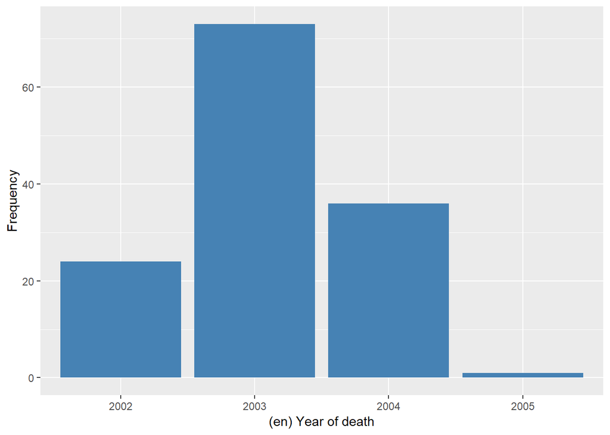

#### 2.1.3.2 Harmonisation algorithm

**R script:**

```r
ELSA_ds_w2 <- tibble(id = dids2)
ELSA_ds_w2$ydeath <- (elsa_eol %>% filter(id %in% dids2))$ydeath
```

#### 2.1.3.3 Statistics of the new harmonised variable

Year of death

| Sample size | Missing values |
| --- | --- |
| 588 | 0 |

Values

|  | 2002 | 2003 | 2004 | 2005 |
| --- | --- | --- | --- | --- |
| Frequency | 67.00 | 227.00 | 200.00 | 94.00 |
| Percentage | 11.39 | 38.61 | 34.01 | 15.99 |

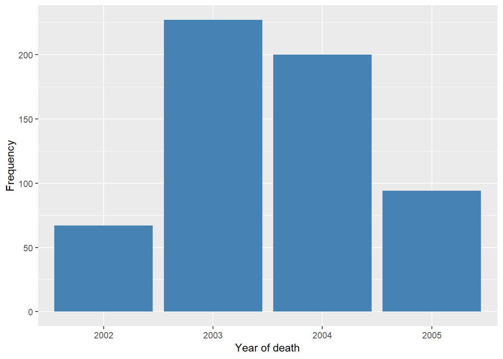

#### 2.1.3.4 Validation

### 2.1.4 Wave 3

#### 2.1.4.1 Study-specific variable description

| **Name** | `EiDateY` |
| --- | --- |
| **Label** | `Year of death` |
| **Table name** | `elsa_eol_w3_archive_v1` |
| **Units** | `years` |
| **Missings** | `-9 = Refused/not answered` `-8 = Don't know` `-1 = Not applicable` |
| **Description** |  |

EiDateY

| Sample size | Missing values |
| --- | --- |
| 374 | 0 |

(en) Year of death

|  | 2002 | 2003 | 2004 | 2005 | 2006 | 2007 |
| --- | --- | --- | --- | --- | --- | --- |
| Frequency | 14.00 | 47.00 | 80.00 | 125.00 | 106.00 | 2.00 |
| Percentage | 3.74 | 12.57 | 21.39 | 33.42 | 28.34 | 0.53 |

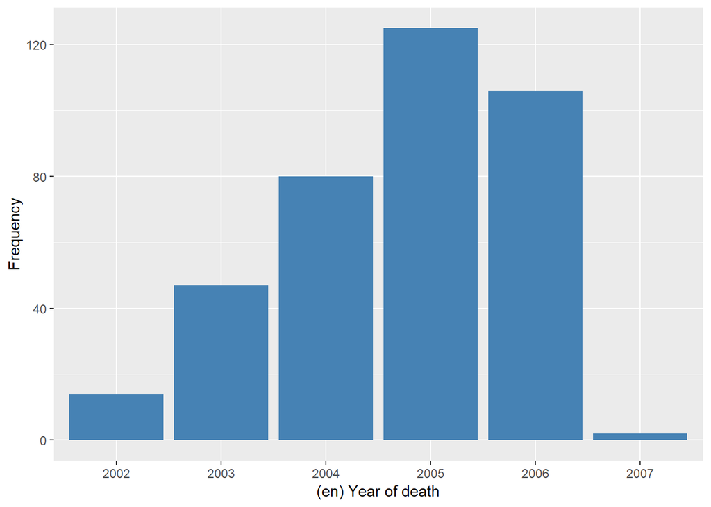

#### 2.1.4.2 Harmonisation algorithm

The harmonized variable is the same than the study-specific variable, but the missing values have to be recoded as follows:

**R script:**

```r
ELSA_ds_w3 <- tibble(id = dids3)
ELSA_ds_w3$ydeath <- (elsa_eol %>% filter(id %in% dids3))$ydeath
```

#### 2.1.4.3 Statistics of the new harmonised variable

Year of death

| Sample size | Missing values |
| --- | --- |
| 519 | 0 |

Values

|  | 2004 | 2005 | 2006 | 2007 |
| --- | --- | --- | --- | --- |
| Frequency | 28.00 | 163.00 | 230.00 | 98.00 |
| Percentage | 5.39 | 31.41 | 44.32 | 18.88 |

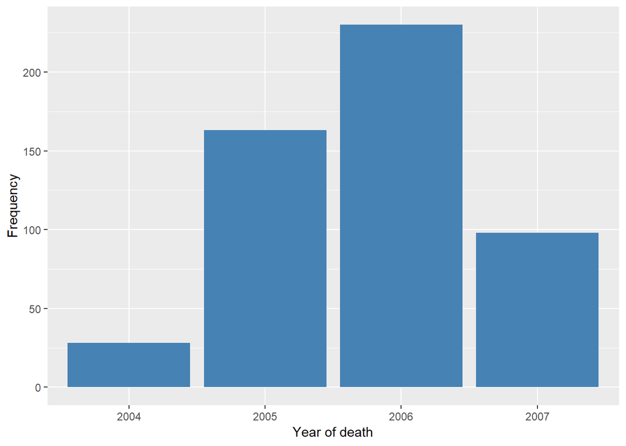

#### 2.1.4.4 Validation

### 2.1.5 Wave 4

#### 2.1.5.1 Study-specific variable description

| **Name** | `EiDateY` |
| --- | --- |
| **Label** | `Year of death` |
| **Table name** | `elsa_eol_w4_archive_v1` |
| **Units** | `years` |
| **Missings** | `-9 = Refused/not answered` `-8 = Don't know` `-1 = Not applicable` |
| **Description** |  |

EiDateY

| Sample size | Missing values |
| --- | --- |
| 237 | 0 |

(en) Year of death

|  | 2004 | 2005 | 2006 | 2007 | 2008 | 2009 |
| --- | --- | --- | --- | --- | --- | --- |
| Frequency | 1.00 | 3.00 | 23.0 | 64 | 133.00 | 13.00 |
| Percentage | 0.42 | 1.27 | 9.7 | 27 | 56.12 | 5.49 |

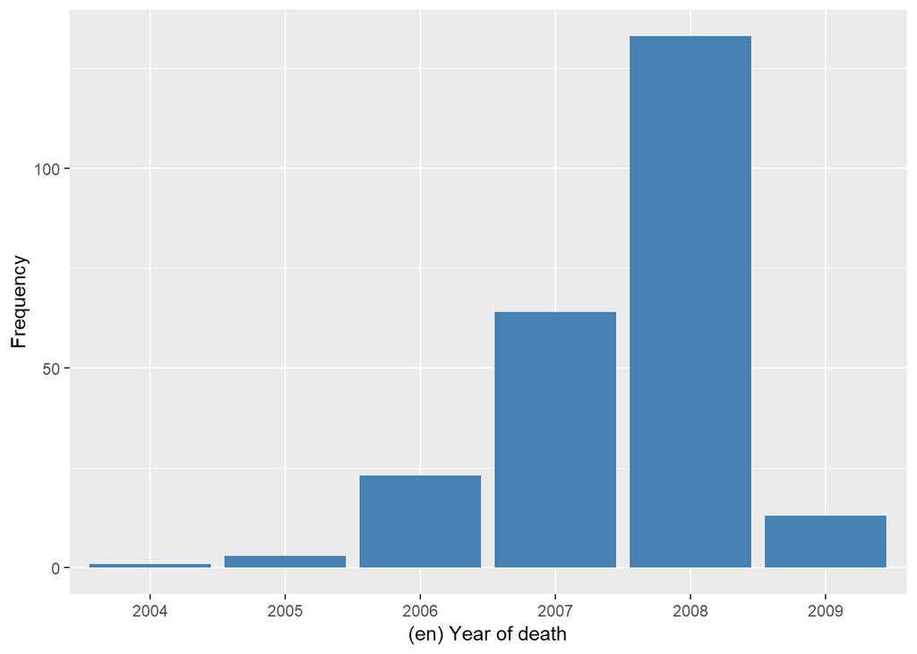

#### 2.1.5.2 Harmonisation algorithm

The harmonized variable is the same than the study-specific variable, but the missing values have to be recoded as follows:

**R script:**

```r
ELSA_ds_w4 <- tibble(id = dids4)
ELSA_ds_w4$ydeath <- (elsa_eol %>% filter(id %in% dids4))$ydeath
```

#### 2.1.5.3 Statistics of the new harmonised variable

Year of death

| Sample size | Missing values |
| --- | --- |
| 574 | 0 |

Values

|  | 2006 | 2007 | 2008 | 2009 |
| --- | --- | --- | --- | --- |
| Frequency | 32.00 | 147.00 | 277.00 | 118.00 |
| Percentage | 5.57 | 25.61 | 48.26 | 20.56 |

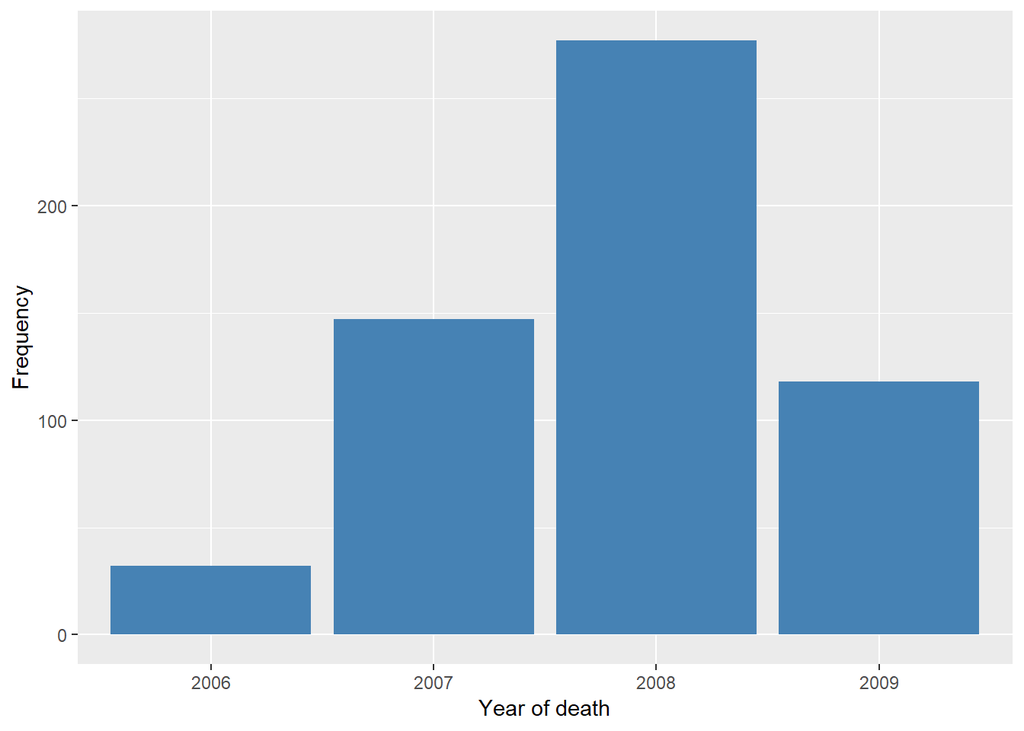

#### 2.1.5.4 Validation

### 2.1.6 Wave 5

#### 2.1.6.1 Study-specific variable description

There is no wave-specific variable.

#### 2.1.6.2 Harmonisation algorithm

The variable is going to computed from the study-specific variable from wave 6, but the missing values have to be recoded as follows:

**R script:**

```r
ELSA_ds_w5 <- tibble(id = dids5)
ELSA_ds_w5$ydeath <- (elsa_eol %>% filter(id %in% dids5))$ydeath
```

#### 2.1.6.3 Statistics of the new harmonised variable

Year of death

| Sample size | Missing values |
| --- | --- |
| 614 | 0 |

Values

|  | 2008 | 2009 | 2010 | 2011 |
| --- | --- | --- | --- | --- |
| Frequency | 30.00 | 176.00 | 264 | 144.00 |
| Percentage | 4.89 | 28.66 | 43 | 23.45 |

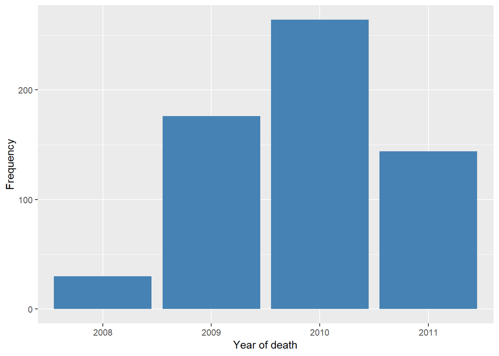

#### 2.1.6.4 Validation

### 2.1.7 Wave 6

#### 2.1.7.1 Study-specific variable description

| **Name** | `EiDateY` |
| --- | --- |
| **Label** | `Year of death` |
| **Table name** | `elsa_endoflife_w6archive` |
| **Units** | `years` |
| **Missings** | `-9 = Refused/not answered` `-8 = Don't know` `-1 = Not applicable` |
| **Description** |  |

EiDateY

| Sample size | Missing values |
| --- | --- |
| 240 | 2 |

(en) Year of death

|  | 2000 | 2007 | 2008 | 2009 | 2010 | 2011 | 2012 |
| --- | --- | --- | --- | --- | --- | --- | --- |
| Frequency | 1.00 | 1.00 | 7.00 | 45.00 | 87.00 | 49.00 | 48 |
| Percentage | 0.42 | 0.42 | 2.92 | 18.75 | 36.25 | 20.42 | 20 |

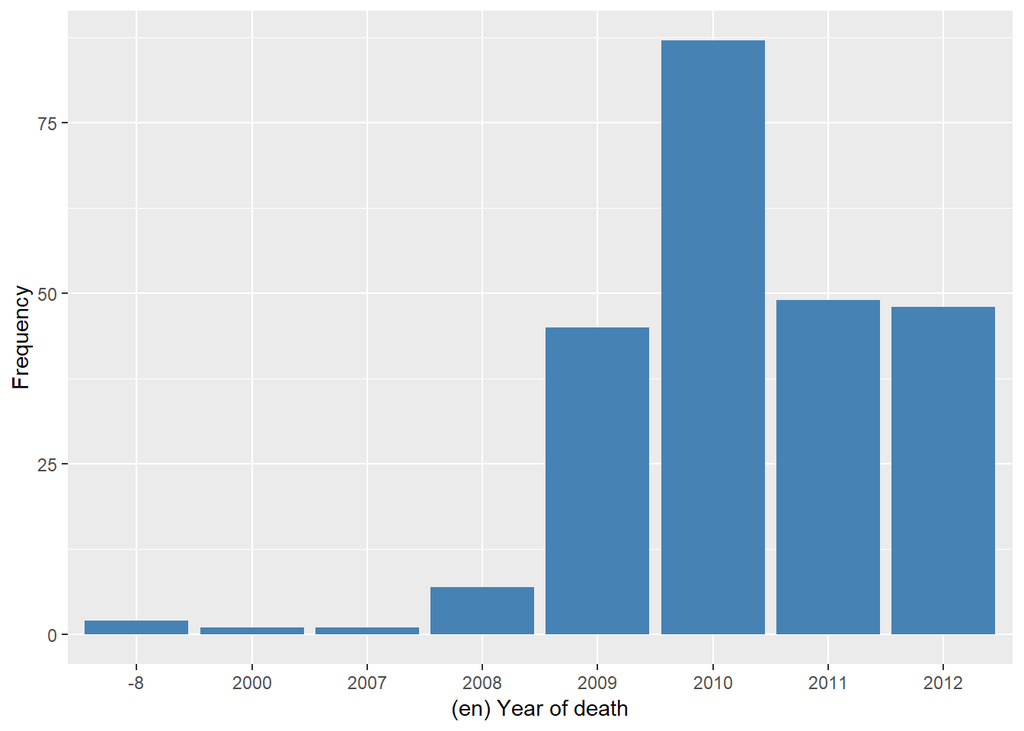

#### 2.1.7.2 Harmonisation algorithm

The harmonized variable is the same than the study-specific variable, but the missing values have to be recoded as follows:

**R script:**

```r
ELSA_ds_w6 <- tibble(id = dids6)
ELSA_ds_w6$ydeath <- (elsa_eol %>% filter(id %in% dids6))$ydeath
```

#### 2.1.7.3 Statistics of the new harmonised variable

Year of death

| Sample size | Missing values |
| --- | --- |
| 305 | 0 |

Values

|  | 2010 | 2011 | 2012 |
| --- | --- | --- | --- |
| Frequency | 26.00 | 172.00 | 107.00 |
| Percentage | 8.52 | 56.39 | 35.08 |

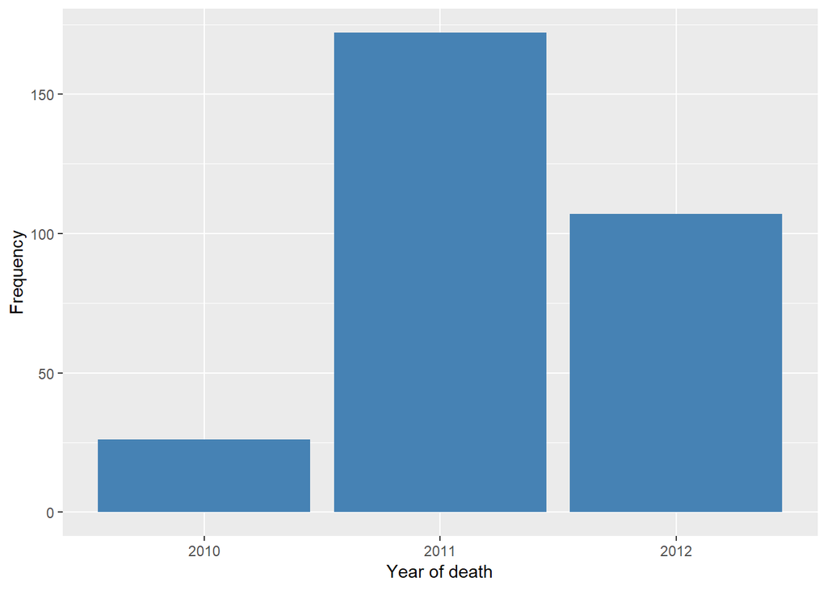

#### 2.1.7.4 Validation

### 2.1.8 Wave 7

Not available data

## 2.2 Summary of descriptive statistics of the harmonised variable accross populations and waves

Year of death

| ydeath | W2 | W3 | W4 | W5 | W6 |
| --- | --- | --- | --- | --- | --- |
| Min. | 2002 | 2004 | 2006 | 2008 | 2010 |
| 1st Qu. | 2003 | 2005 | 2007 | 2009 | 2011 |
| Median | 2004 | 2006 | 2008 | 2010 | 2011 |
| Mean | 2004 | 2006 | 2008 | 2010 | 2011 |
| 3rd Qu. | 2004 | 2006 | 2008 | 2010 | 2012 |
| Max. | 2005 | 2007 | 2009 | 2011 | 2012 |
| No-missings | 588 | 519 | 574 | 614 | 305 |
| 991 | 0 | 0 | 0 | 0 | 0 |
| 992 | 0 | 0 | 0 | 0 | 0 |
| 993 | 0 | 0 | 0 | 0 | 0 |
| 994 | 0 | 0 | 0 | 0 | 0 |
| 995 | 0 | 0 | 0 | 0 | 0 |
| 996 | 0 | 0 | 0 | 0 | 0 |
| 997 | 0 | 0 | 0 | 0 | 0 |
| 998 | 0 | 0 | 0 | 0 | 0 |
| 999 | 0 | 0 | 0 | 0 | 0 |
| NA | 0 | 0 | 0 | 0 | 0 |
| sample size | 588 | 519 | 574 | 614 | 305 |

# 3 Quality estimation

No comments